# HW 03

Author

Lucas Smith

```r
pkgs = c("tidyverse", "grid", "gridExtra", "ggplot2", "reshape", "ggalt", "likert", "ggstats", "ggimage", "jpeg" ,"png")
for (pkg in pkgs) {
  if (!require(pkg, character.only=TRUE)) {
    install.packages(pkg)
    library(pkg, character.only = TRUE)
  }
}
```

[output not shown]

## 1 - Du Bois challenge.

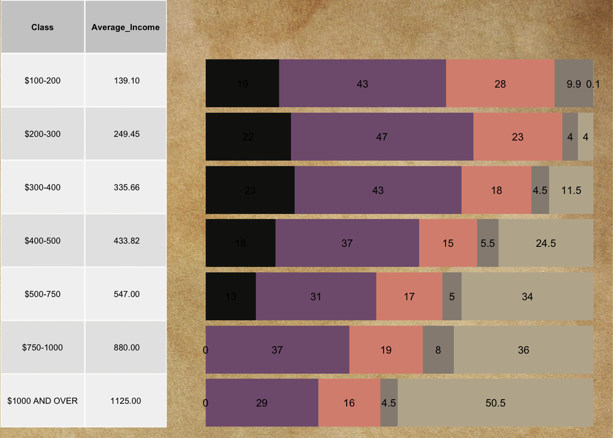

```r
library(jpeg)
parchment <- readJPEG("images/parchment.jpg")
bg <- rasterGrob(parchment, width = unit(1,"npc"), height = unit(1,"npc"))

dubois <- read_csv("data/income.csv")
db <- pivot_longer(dubois,
                   c("Rent", "Food", "Clothes", "Tax", "Other"),
                   names_to="income_type", values_to = "percent")
order <- rev(c("$100-200",
               "$200-300",
               "$300-400",
               "$400-500",
               "$500-750",
               "$750-1000",
               "$1000 AND OVER"
               )
             )
color_vals = c("Rent" = "#141512", "Food" = "#805D7D",
               "Clothes" = "#DA907F", "Tax"="#958c82",
               "Other"="#BDB39C"
               )
x_ordering <- c("Rent", "Food", "Clothes", "Tax", "Other")

plt <- ggplot(db,
              aes(x=percent,
                  y=Class,
                  fill=factor(income_type,
                              levels=rev(x_ordering)
                              ),
                  )) +
  geom_col(position="stack") +
  geom_text(aes(label=percent), position = position_stack(vjust = 0.5),
            size=3)

plt <- plt +
        guides(fill=FALSE) +
        theme(axis.text.x=element_blank(),
             axis.title.x=element_blank(),
             axis.ticks.x=element_blank(),
             axis.ticks.y = element_blank(),
             legend.position = NULL,
             plot.margin=margin(0,0,0,0),
             plot.background = element_blank(),
             axis.text.y = element_blank(),
             panel.background=element_blank(),
             panel.grid.minor=element_blank(),
             panel.grid.major=element_blank()) +
        labs(x="", y="") +
        scale_y_discrete(limits=order) +
        scale_fill_manual(values=color_vals)
tabledata <- dubois |> select(Class, Average_Income)
tab <- tableGrob(tabledata, rows=NULL, theme=ttheme_default(base_size = 7,
                                                           panel.background=element_blank()))
tab$heights <- unit(rep(1/nrow(tab), nrow(tab) ), "npc")

data <- grid.arrange(
  arrangeGrob(tab, nullGrob(), heights=c(200, 5)),
  arrangeGrob(nullGrob(), plt, heights=c(4, 30)),
  widths=c(3, 8)
)

grid.raster(parchment, width=unit(1, "npc"), height=unit(1, "npc"))
grid.draw(data)
```

## 2 - COVID survey - interpret

First I would like to mention that I do not like the Likert scaling used in the questionnaire. Most Likert scales have 5 as `Strongly Agree`, yes for this one it is 1. This provides a difference in the user interaction and user experience, and can cause some confusion on reporting as it is an inconsistent experience when compared to other standardized questions that use the Likert scale. Anyway.

There is a lot going on with this visualization. When I saw this visualization for the first time, I felt overwhelmed at the amount of information, and I believe it is important to understand why.

- The first thing that I notice is the challenge in deciphering any given point. There are three dimensions shown in the graph: the question, the stratification of individual, and the sub-stratification. To view one range, you need to carefully look back and forth a few times to ensure you are on the right scale, which presents a high cognitive load.
- The second question I noticed is the challenge to discern anything useful. There is so much data, yet at the same time the question becomes: how is any of this useful?

As for the results:

- Most scores have a low range, from 1-2.
- To answer the question of whether I believe it is in line with my intuition, I say: it depends. As a general belief system, I believe in the scientific community and as seeing the good in others as well. I believe that most people thought the vaccines were good and were a benefit to society. That part of me does want to go back to the Likert scaling inversion I mentioned before, and say that most people did not read the specifics of what *this* questionnaire’s 1 and 5 meant, and assumed that 1 meant disagree and 5 meant agree.
- The other part of me thinks that it is feasible that many people were skeptical of the vaccine at the time it was released. It was released under different circumstances than a regular vaccine, and I do remember skepticism at the time.

Examples

## 3 - COVID survey - reconstruct

```r
covid <- read_csv("data/covid-survey.csv")
```

```
──────────────────────────────────────────────────────── Delimiter: "," chr
(14): likert_survey, ...2, ...3, ...4, ...5, ...6, ...7, ...8, ...9, ......
```

```r
covid <- read_csv("data/covid-survey.csv", skip=1)
```

```r
# filter out any no longer useful
colnames <- colnames(covid[, -1])
filtered_missing_rows <- covid |> filter(!if_all(.cols=colnames, is.na))
dim(filtered_missing_rows)
```

```
[1] 1111   14
```

```r
# I moved things over to factored in the second code chunk

survey_response_values <- c(
  "1" = "Strongly agree",
  "2" = "Somewhat agree",
  "3" = "Neither agree nor disagree",
  "4" = "Somewhat disagree",
  "5" = "Strongly disagree"
)

relabeled_cols <- colnames(covid[, seq(from=9, to=14)])
covid2 <- covid

covid <- covid |> mutate(across(relabeled_cols, ~ survey_response_values[as.character(.)]))
covid <- covid |>
  mutate(exp_already_vax=case_when(
    exp_already_vax== 0 ~ "No", exp_already_vax== 1 ~ "Yes"
  )) |>
  mutate(exp_flu_vax=case_when(
    exp_flu_vax== 0 ~ "No", exp_flu_vax== 1 ~ "Yes"
  )) |>
  mutate(exp_profession=case_when(
    exp_profession== 0 ~ "Medical", exp_profession== 1 ~ "Nursing"
  )) |>
  mutate(exp_gender=case_when(
    exp_gender== 0 ~ "Male",
    exp_gender== 1 ~ "Female",
    exp_gender== 2 ~ "Non-binary third gender",
    exp_gender== 3 ~ "Prefer not to say"
  )) |>
  mutate(exp_race=case_when(
    exp_race== 1 ~ "American Indian / Alaskan Native",
    exp_race== 2 ~ "Asian",
    exp_race== 3 ~ "Black / African American",
    exp_race== 4 ~ "Native Hawaiian / Other Pacific Islander",
    exp_race== 5 ~ "White"
  )) |>
  mutate(exp_ethnicity=case_when(
    exp_ethnicity== 1 ~ "Hispanic / Latino",
    exp_ethnicity== 2 ~ "Non-Hispanic/Non-Latino"
  )) |>
  mutate(exp_age_bin=case_when(
    exp_age_bin== 0 ~ "<20",
    exp_age_bin== 20 ~ "21-25",
    exp_age_bin== 25  ~ "26-30",
    exp_age_bin== 30 ~ ">30"
  ))


dim(covid)
```

```
[1] 1121   14
```

```r
coviddata <- covid2 |>
  mutate(exp_already_vax=as.factor(case_when(
    exp_already_vax== 0 ~ "No", exp_already_vax== 1 ~ "Yes"
  ))) |>
  mutate(exp_flu_vax=as.factor(case_when(
    exp_flu_vax== 0 ~ "No", exp_flu_vax== 1 ~ "Yes"
  ))) |>
  mutate(exp_profession=as.factor(case_when(
    exp_profession== 0 ~ "Medical", exp_profession== 1 ~ "Nursing"
  ))) |>
  mutate(exp_gender=as.factor(case_when(
    exp_gender== 0 ~ "Male",
    exp_gender== 1 ~ "Female",
    exp_gender== 2 ~ "Non-binary third gender",
    exp_gender== 3 ~ "Prefer not to say"
  ))) |>
  mutate(exp_race=as.factor(case_when(
    exp_race== 1 ~ "American Indian / Alaskan Native",
    exp_race== 2 ~ "Asian",
    exp_race== 3 ~ "Black / African American",
    exp_race== 4 ~ "Native Hawaiian / Other Pacific Islander",
    exp_race== 5 ~ "White"
  ))) |>
  mutate(exp_ethnicity=as.factor(case_when(
    exp_ethnicity== 1 ~ "Hispanic / Latino",
    exp_ethnicity== 2 ~ "Non-Hispanic/Non-Latino"
  ))) |>
  mutate(exp_age_bin=as.factor(case_when(
    exp_age_bin== 0 ~ "<20",
    exp_age_bin== 20 ~ "21-25",
    exp_age_bin== 25  ~ "26-30",
    exp_age_bin== 30 ~ ">30"
  )))

covid_survey_longer <- coviddata |>
  pivot_longer(
    cols = starts_with("exp_"),
    names_to = "explanatory",
    values_to = "explanatory_value"
  ) |>
  filter(!is.na(explanatory_value)) |>
  pivot_longer(
    cols = starts_with("resp_"),
    names_to = "response",
    values_to = "response_value"
  )
```

```r
tibble(covid_survey_longer)
```

```
# A tibble: 43,362 × 5
   response_id explanatory    explanatory_value response          response_value
         <dbl> <chr>          <fct>             <chr>                      <dbl>
 1           1 exp_profession Nursing           resp_safety                    5
 2           1 exp_profession Nursing           resp_confidence_…              2
 3           1 exp_profession Nursing           resp_concern_saf…              2
 4           1 exp_profession Nursing           resp_feel_safe_a…              1
 5           1 exp_profession Nursing           resp_will_recomm…              1
 6           1 exp_profession Nursing           resp_trust_info                1
 7           1 exp_flu_vax    Yes               resp_safety                    5
 8           1 exp_flu_vax    Yes               resp_confidence_…              2
 9           1 exp_flu_vax    Yes               resp_concern_saf…              2
10           1 exp_flu_vax    Yes               resp_feel_safe_a…              1
# ℹ 43,352 more rows
```

```r
# viewing to verify everything is alright, removing nulls because otherwise it doesn't work
covid_survey_summary_stats_by_group <- covid_survey_longer |>
  mutate(response_value = as.numeric(response_value)) |>
  group_by(explanatory, explanatory_value, response) |>
  summarise(
    mean=mean(response_value, na.rm=TRUE),
    low=quantile(response_value, .1, na.rm=TRUE),
    high=quantile(response_value,.9, na.rm=TRUE)  )
covid_survey_summary_stats_by_group
```

```
# A tibble: 120 × 6
# Groups:   explanatory, explanatory_value [20]
   explanatory explanatory_value response                 mean   low  high
   <chr>       <fct>             <chr>                   <dbl> <dbl> <dbl>
 1 exp_age_bin <20               resp_concern_safety      3.35     2   4.4
 2 exp_age_bin <20               resp_confidence_science  1.65     1   2.4
 3 exp_age_bin <20               resp_feel_safe_at_work   1.71     1   3.8
 4 exp_age_bin <20               resp_safety              1.41     1   2
 5 exp_age_bin <20               resp_trust_info          1.41     1   2
 6 exp_age_bin <20               resp_will_recommend      1.35     1   1.8
 7 exp_age_bin >30               resp_concern_safety      3.01     1   5
 8 exp_age_bin >30               resp_confidence_science  1.71     1   3
 9 exp_age_bin >30               resp_feel_safe_at_work   1.77     1   4
10 exp_age_bin >30               resp_safety              1.85     1   4
# ℹ 110 more rows
```

- Now group the data (`covid_survey_longer`) again, this time only by `response`, in order to calculate the same summary statistics for each response variable (mean, 10th percentile, and 90th percentile), not conditioned on the explanatory variables. Name this new data frame `covid_survey_summary_stats_all`. It should look like the following:

```r
# ended up adding the explanatory value="" on this to make it like yours
covid_survey_summary_stats_all <- covid_survey_longer |>
  group_by(response) |>
  summarise(
    mean=mean(response_value, na.rm=TRUE),
    low=quantile(response_value, .1, na.rm=TRUE),
    high=quantile(response_value,.9, na.rm=TRUE)  ) |>
  mutate(
    explanatory = "All",
    explanatory_value = ""
  )


covid_survey_summary_stats_all
```

```
# A tibble: 6 × 6
  response                 mean   low  high explanatory explanatory_value
  <chr>                   <dbl> <dbl> <dbl> <chr>       <chr>
1 resp_concern_safety      3.28     1     5 All         ""
2 resp_confidence_science  1.43     1     2 All         ""
3 resp_feel_safe_at_work   1.35     1     2 All         ""
4 resp_safety              2.03     1     5 All         ""
5 resp_trust_info          1.40     1     2 All         ""
6 resp_will_recommend      1.21     1     2 All         ""
```

- Bind the two data frames of summary statistics you created `covid_survey_summary_stats_all` and `covid_survey_summary_stats_by_group` together by row. Name the resulting data frame `covid_survey_summary_stats`. It should look like the following:

```r
# merging both row wise
covid_survey_summary_stats <- bind_rows(covid_survey_summary_stats_all, covid_survey_summary_stats_by_group)

covid_survey_summary_stats
```

```
# A tibble: 126 × 6
   response                 mean   low  high explanatory explanatory_value
   <chr>                   <dbl> <dbl> <dbl> <chr>       <chr>
 1 resp_concern_safety      3.28     1   5   All         ""
 2 resp_confidence_science  1.43     1   2   All         ""
 3 resp_feel_safe_at_work   1.35     1   2   All         ""
 4 resp_safety              2.03     1   5   All         ""
 5 resp_trust_info          1.40     1   2   All         ""
 6 resp_will_recommend      1.21     1   2   All         ""
 7 resp_concern_safety      3.35     2   4.4 exp_age_bin "<20"
 8 resp_confidence_science  1.65     1   2.4 exp_age_bin "<20"
 9 resp_feel_safe_at_work   1.71     1   3.8 exp_age_bin "<20"
10 resp_safety              1.41     1   2   exp_age_bin "<20"
# ℹ 116 more rows
```

## 4 - COVID survey - re-reconstruct

```r
csss <- covid_survey_summary_stats
# I saw that factors were being used, so tried that.
csss <- csss |> mutate(
    explanatory = factor(explanatory),
    explanatory_value = factor(explanatory_value),
    response = factor(response)
  ) |>
  droplevels()

#
p <- ggplot(csss, aes(y=explanatory_value)) +
  geom_segment(aes(x=low, xend=high), linewidth=.3) +
  theme(
      legend.position=NULL,
      axis.ticks.x=element_blank(),
      axis.ticks.y=element_blank(),
      panel.background = element_blank()
    ) +
    geom_point(aes(x=mean), size=.5) +
    geom_errorbar(aes(xmin=low, xmax=high), width=0.4)
  labs(x="", y="")
```

```
$x
[1] ""

$y
[1] ""

attr(,"class")
[1] "labels"
```

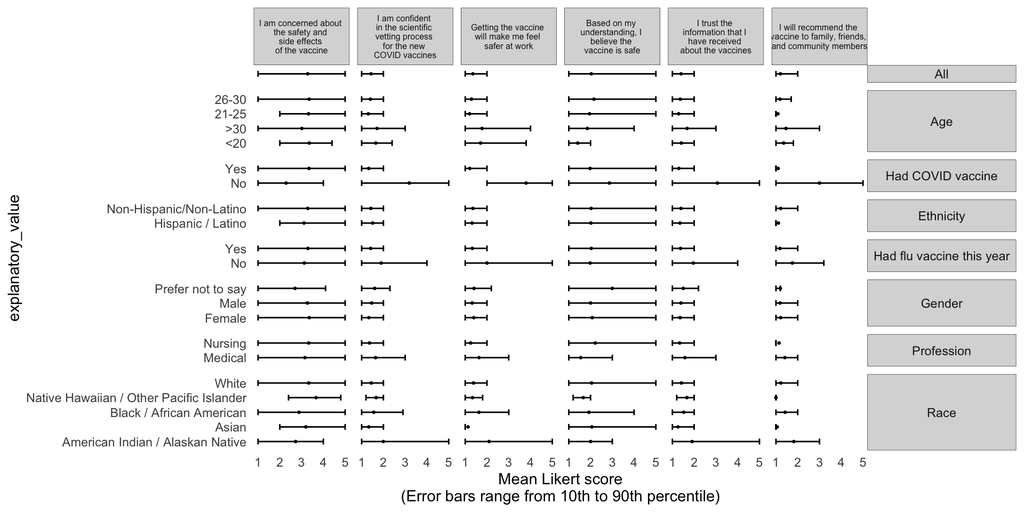

```r
xlabels <- c(
  "resp_safety" = "Based on my \nunderstanding, I \nbelieve the \nvaccine is safe",
"resp_confidence_science" = "I am confident \nin the scientific \nvetting process \nfor the new \nCOVID vaccines",
"resp_feel_safe_at_work" = "Getting the vaccine \nwill make me feel \nsafer at work",
"resp_will_recommend" = "I will recommend the \nvaccine to family, friends, \nand community members",
"resp_trust_info" = "I trust the \ninformation that I \nhave received \nabout the vaccines",
"resp_concern_safety" = "I am concerned about \nthe safety and \nside effects \nof the vaccine"
)

ylabels <- c(
  "exp_age_bin" = "Age",
"exp_gender" = "Gender",
"exp_race" = "Race",
"exp_ethnicity" = "Ethnicity",
"exp_profession" = "Profession",
"exp_already_vax" = "Had COVID vaccine",
"exp_flu_vax" = "Had flu vaccine this year"
)

p + facet_grid(vars(explanatory), vars(response), scales="free_y", space="free_y", drop=TRUE,
               labeller = labeller(explanatory = ylabels, response=xlabels)) +
  theme(
    strip.text.x = element_text(size=6),
    strip.text.y = element_text(angle=0),
    strip.background = element_rect(color = "black", size = .2)
  ) + labs(x="Mean Likert score\n(Error bars range from 10th to 90th percentile)")
```